# EDA on Prosper loan data

Jörg Strebel

Jan. 3rd 2018

========================================================

```r
# Load the Data
#
setwd("/home/jstrebel/devel/udacity/Ch5_Project/")
prosper_df = read.csv("prosperLoanData.csv", fill = FALSE,
                      stringsAsFactors = FALSE,
                      na.strings=c("", "NA"))

# Check and remove duplicates in key field ListingNumber
# unique() does not work on this data frame
prosper_df %>% group_by(LoanKey) %>% summarise(n = n()) %>% filter(n >1)
```

```
## # A tibble: 827 x 2
##                    LoanKey     n
##                      <chr> <int>
##  1 001D370202065948445765E     2
##  2 009C36959125842600757B0     2
##  3 01663704101754715CF7C56     2
##  4 017637048068403015E470D     2
##  5 01C83707282210922790778     2
##  6 02163700809231365A56A1C     2
##  7 0224369791751850396C2F3     2
##  8 0275370118102352450205B     2
##  9 02983704628886994482743     2
## 10 02D137079845719197ACFE8     2
## # ... with 817 more rows
```

```r
pr_df <- prosper_df %>% distinct(LoanKey, .keep_all = TRUE)

# Combine variables CreditGrade and ProsperRating..Alpha.
pr_df$AllCreditGrade <- ifelse(is.na(pr_df$CreditGrade) == TRUE ,
                               pr_df$ProsperRating..Alpha. ,
                               pr_df$CreditGrade)

# Create new LoanStatus with only one Past Due level
pr_df$LoanStatus.Simple <- sub("^Past Due.+","Past Due",pr_df$LoanStatus,
                               perl = TRUE)

# parse time and date columns
pr_df$LoanOriginationDate <- as.Date(pr_df$LoanOriginationDate,
                                     "%Y-%m-%d %H:%M:%S")
pr_df$ListingCreationDate <- as.Date(pr_df$ListingCreationDate,
                                     "%Y-%m-%d %H:%M:%S")
pr_df$LoanSetupTime <- as.numeric(
  difftime(pr_df$LoanOriginationDate, pr_df$ListingCreationDate,
                                units = "days"))

# NA values
pr_df <- replace_na(pr_df, list(AllCreditGrade ="Unknown"))


# encode (ordered) factors
pr_df$AllCreditGrade <- factor(pr_df$AllCreditGrade,
                               levels = c("AA", "A","B", "C","D","E","HR",
                                          "NC","Unknown"), ordered = TRUE)

pr_df$LoanStatus.Simple <- factor(pr_df$LoanStatus.Simple)
pr_df$IncomeRange <- factor(pr_df$IncomeRange,
                                  levels = c("Not employed",
                                             "$0",
                                             "$1-24,999",
                                             "$25,000-49,999",
                                             "$50,000-74,999",
                                             "$75,000-99,999",
                                             "$100,000+",
                                             "Not displayed"), ordered = TRUE)
pr_df$IsBorrowerHomeowner <- factor(pr_df$IsBorrowerHomeowner)

# does StatedMonthlyIncome match IncomeRange?
pr_df$YearlyIncome <- pr_df$StatedMonthlyIncome*12
head(pr_df[,c("YearlyIncome", "IncomeRange")], n=20)
```

```
##    YearlyIncome    IncomeRange
## 1         37000 $25,000-49,999
## 2         73500 $50,000-74,999
## 3         25000  Not displayed
## 4         34500 $25,000-49,999
## 5        115000      $100,000+
## 6        100000      $100,000+
## 7         25000 $25,000-49,999
## 8         40269 $25,000-49,999
## 9         40000 $25,000-49,999
## 10        90000 $75,000-99,999
## 11        20000      $1-24,999
## 12        29000 $25,000-49,999
## 13        70000 $50,000-74,999
## 14       130000      $100,000+
## 15        66000 $50,000-74,999
## 16        99500 $75,000-99,999
## 17        70000  Not displayed
## 18        75000 $75,000-99,999
## 19        36900 $25,000-49,999
## 20        62000 $50,000-74,999
```

```r
# rows and columns
dim(pr_df)
```

```
## [1] 113066     85
```

```r
# count NA values in each column
print("Number of NA values in each variable")
```

```
## [1] "Number of NA values in each variable"
```

```r
apply(pr_df, 2, function(x) sum(is.na(x)))
```

```
##                          ListingKey                       ListingNumber
##                                   0                                   0
##                 ListingCreationDate                         CreditGrade
##                                   0                               84113
##                                Term                          LoanStatus
##                                   0                                   0
##                          ClosedDate                         BorrowerAPR
##                               57990                                  25
##                        BorrowerRate                         LenderYield
##                                   0                                   0
##             EstimatedEffectiveYield                       EstimatedLoss
##                               29084                               29084
##                     EstimatedReturn             ProsperRating..numeric.
##                               29084                               29084
##               ProsperRating..Alpha.                        ProsperScore
##                               29084                               29084
##           ListingCategory..numeric.                       BorrowerState
##                                   0                                5515
##                          Occupation                    EmploymentStatus
##                                3529                                2255
##            EmploymentStatusDuration                 IsBorrowerHomeowner
##                                7625                                   0
##                    CurrentlyInGroup                            GroupKey
##                                   0                               99727
##                    DateCreditPulled               CreditScoreRangeLower
##                                   0                                 591
##               CreditScoreRangeUpper             FirstRecordedCreditLine
##                                 591                                 697
##                  CurrentCreditLines                     OpenCreditLines
##                                7604                                7604
##          TotalCreditLinespast7years               OpenRevolvingAccounts
##                                 697                                   0
##         OpenRevolvingMonthlyPayment                InquiriesLast6Months
##                                   0                                 697
##                      TotalInquiries                CurrentDelinquencies
##                                1159                                 697
##                    AmountDelinquent             DelinquenciesLast7Years
##                                7622                                 990
##            PublicRecordsLast10Years           PublicRecordsLast12Months
##                                 697                                7604
```

[output cut: 31 more lines]

```
##                                   0                                   0
##                   LP_CollectionFees               LP_GrossPrincipalLoss
##                                   0                                   0
##                 LP_NetPrincipalLoss     LP_NonPrincipalRecoverypayments
##                                   0                                   0
##                       PercentFunded                     Recommendations
##                                   0                                   0
##          InvestmentFromFriendsCount         InvestmentFromFriendsAmount
##                                   0                                   0
##                           Investors                      AllCreditGrade
##                                   0                                   0
##                   LoanStatus.Simple                       LoanSetupTime
##                                   0                                   0
##                        YearlyIncome
##                                   0
```

This project conducts an exploratory data analysis on loan data from the Prosper company. This company runs a Web-based peer-to-peer lending business; borrowers create listings, in which they describe the loan details. Investors then provide the money. During the term, borrowers pay fixed monthly amounts and investors receive a portion of those payments directly to their Prosper account. See https://www.prosper.com/plp/loans/ for further information.

This assignment relies on the student to ask his own questions about this data set, so I’ll put forward my research questions, which are guiding my variable selection, the data transformations and the analysis.

The overarching question is, how good Prosper works for both borrowers and investors.

- What are the factors that determine the loan status, esp. for successful loans?
- What are the factors that determine the loan setup time, e.g. how long does the borrower have to wait for the loan?

The consideration of the time span, in which the data has been collected, is of high importance, as recessions and other economic factors might influence the borrowing and investing behaviour.

## Problems with variables

- There is a fundamental problem with all date and time fields. As there is no timezone given, it is unclear, how the time and date values can be interpreted.
- The variable BorrowerAPR not used because of NA values and because BorrowerRate is complete.
- The variable InvestmentfromFriendsCount could be unreliable, as the Prosper documentation does not reveal, how friends are tracked. Is there a Prosper social network?
- DebtToIncomeRatio, an important variable for any credit score, has ca. 7.5% missing values. The affected rows will be discarded if this variable is needed.
- Consistency of StatedMonthlyIncome and IncomeRange: after calculating the yearly income from the StatedMonthlyIncome, a first superficial, visual comparison between the two variables was conducted. The yearly income seems to match the IncomeRange variable, although the Prosper documentation does not reveal, if both variables are created from the same data.

# Univariate Plots Section

The following variables are used for closer inspection in this report (i.e. univariate, bivariate and multivariate plots): AllCreditGrade, Term, LoanStatus.Simple, BorrowerRate, IsBorrowerHomeowner, IncomeRange, StatedMonthlyIncome, MonthlyLoanPayment, PercentFunded, InvestmentFromFriendsCount, Investors, LoanOriginalAmount, YearlyIncome, LoanSetupTime.

```
## 'data.frame':    113066 obs. of  14 variables:
##  $ AllCreditGrade            : Ord.factor w/ 9 levels "AA"<"A"<"B"<"C"<..: 4 2 7 2 5 3 6 4 1 4 ...
##  $ Term                      : int  36 36 36 36 36 60 36 36 36 60 ...
##  $ LoanStatus.Simple         : Factor w/ 7 levels "Cancelled","Chargedoff",..: 3 4 3 4 4 4 4 4 4 4 ...
##  $ BorrowerRate              : num  0.158 0.092 0.275 0.0974 0.2085 ...
##  $ IsBorrowerHomeowner       : Factor w/ 2 levels "False","True": 2 1 1 2 2 2 1 1 2 1 ...
##  $ IncomeRange               : Ord.factor w/ 8 levels "Not employed"<..: 4 5 8 4 7 7 4 4 4 6 ...
##  $ StatedMonthlyIncome       : num  3083 6125 2083 2875 9583 ...
##  $ MonthlyLoanPayment        : num  330 319 123 321 564 ...
##  $ PercentFunded             : num  1 1 1 1 1 1 1 1 1 1 ...
##  $ InvestmentFromFriendsCount: int  0 0 0 0 0 0 0 0 0 0 ...
##  $ Investors                 : int  258 1 41 158 20 1 1 1 1 19 ...
##  $ LoanOriginalAmount        : int  9425 10000 3001 10000 15000 15000 3000 10000 10000 13500 ...
##  $ YearlyIncome              : num  37000 73500 25000 34500 115000 ...
##  $ LoanSetupTime             : num  17 4 12 10 6 10 6 8 10 7 ...
```

```
##  AllCreditGrade       Term                   LoanStatus.Simple
##  AA     : 8834   Min.   :12.0   Cancelled             :    5
##  A      :17705   1st Qu.:36.0   Chargedoff            :11992
##  B      :19757   Median :36.0   Completed             :38061
##  C      :23745   Mean   :40.8   Current               :55730
##  D      :19323   3rd Qu.:36.0   Defaulted             : 5018
##  E      :13005   Max.   :60.0   FinalPaymentInProgress:  203
##  HR     :10425                  Past Due              : 2057
##  NC     :  141
##  Unknown:  131
##   BorrowerRate    IsBorrowerHomeowner         IncomeRange
##  Min.   :0.0000   False:56014         Not employed  :  806
##  1st Qu.:0.1340   True :57052         $0            :  621
##  Median :0.1840                       $1-24,999     : 7241
##  Mean   :0.1929                       $25,000-49,999:31940
##  3rd Qu.:0.2506                       $50,000-74,999:30749
##  Max.   :0.4975                       $75,000-99,999:16780
##                                       $100,000+     :17188
##                                       Not displayed : 7741
##
##  StatedMonthlyIncome MonthlyLoanPayment PercentFunded
##  Min.   :      0     Min.   :   0.0     Min.   :0.7000
##  1st Qu.:   3199     1st Qu.: 130.9     1st Qu.:1.0000
##  Median :   4667     Median : 217.4     Median :1.0000
##  Mean   :   5605     Mean   : 271.9     Mean   :0.9986
##  3rd Qu.:   6825     3rd Qu.: 370.6     3rd Qu.:1.0000
##  Max.   :1750003     Max.   :2251.5     Max.   :1.0125
##
##
##
##  InvestmentFromFriendsCount   Investors       LoanOriginalAmount
##  Min.   : 0.00000           Min.   :   1.00   Min.   : 1000
##  1st Qu.: 0.00000           1st Qu.:   2.00   1st Qu.: 4000
##  Median : 0.00000           Median :  44.00   Median : 6300
##  Mean   : 0.02364           Mean   :  80.88   Mean   : 8315
##  3rd Qu.: 0.00000           3rd Qu.: 116.00   3rd Qu.:12000
##  Max.   :33.00000           Max.   :1189.00   Max.   :35000
##
##
##
##   YearlyIncome      LoanSetupTime
##  Min.   :       0   Min.   :   1.00
##  1st Qu.:   38393   1st Qu.:   5.00
##  Median :   56000   Median :   9.00
##  Mean   :   67261   Mean   :  12.16
##  3rd Qu.:   81896   3rd Qu.:  13.00
##  Max.   :21000035   Max.   :1095.00
##
##
##
```

```
## [1] "Number of NA values"
```

```
##             AllCreditGrade                       Term
##                          0                          0
##          LoanStatus.Simple               BorrowerRate
##                          0                          0
##        IsBorrowerHomeowner                IncomeRange
##                          0                          0
##        StatedMonthlyIncome         MonthlyLoanPayment
##                          0                          0
##              PercentFunded InvestmentFromFriendsCount
##                          0                          0
##                  Investors         LoanOriginalAmount
##                          0                          0
##               YearlyIncome              LoanSetupTime
##                          0                          0
```

Above, the variable types and summary of the subset is given. The variables show no NA values. The variable LoanOriginationDate introduces a time dimension into the data set, which should give a good first impression of the temporal distribution of the loans.

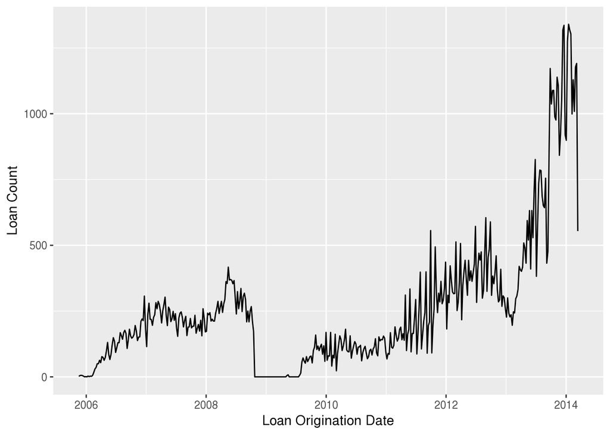

```
##         Min.      1st Qu.       Median         Mean      3rd Qu.
## "2005-11-15" "2008-09-26" "2012-06-20" "2011-07-14" "2013-09-11"
##         Max.
## "2014-03-12"
```

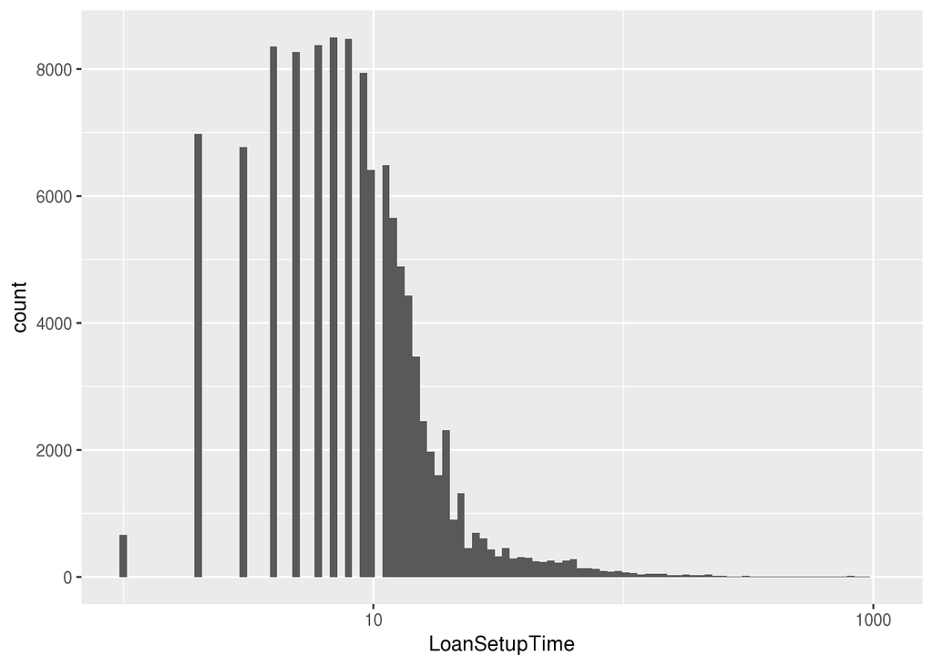

```
##    Min. 1st Qu.  Median    Mean 3rd Qu.    Max.
##    1.00    5.00    9.00   12.16   13.00 1095.00
```

[output not shown]

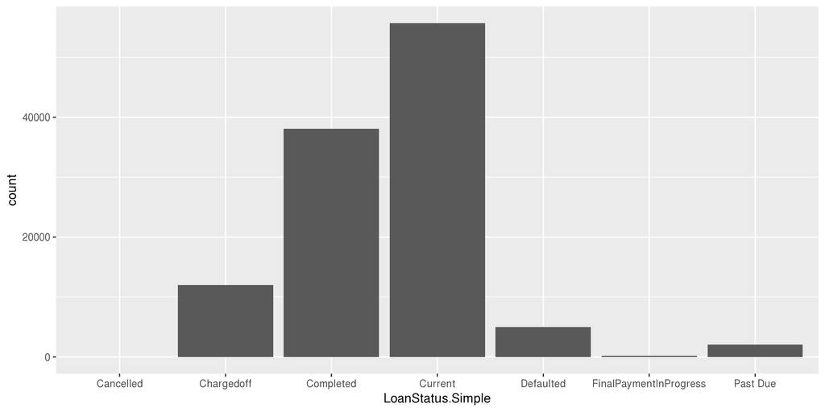

```
##
##              Cancelled             Chargedoff              Completed
##                      5                  11992                  38061
##                Current              Defaulted FinalPaymentInProgress
##                  55730                   5018                    203
##               Past Due
##                   2057
```

LoanStatus.Simple is a newly calculated variable and is based on the LoanStatus variable from the data set. All different “Past Due” categories are merged into one “Past Due” category, as I am not interested in the number of days that the borrower is past due. Most loans are current, i.e. are running as expected.

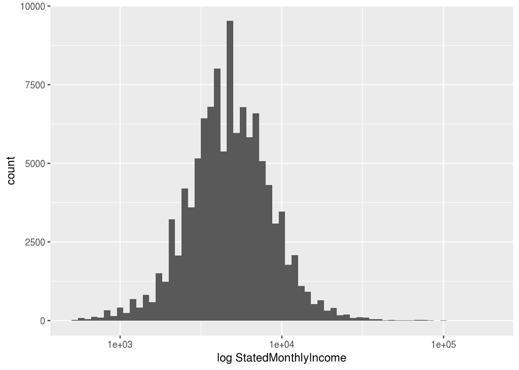

```
##    Min. 1st Qu.  Median    Mean 3rd Qu.    Max.
##       0    3199    4667    5605    6825 1750000
```

The variable YearlyIncome has similar properties and will not be further investigated.

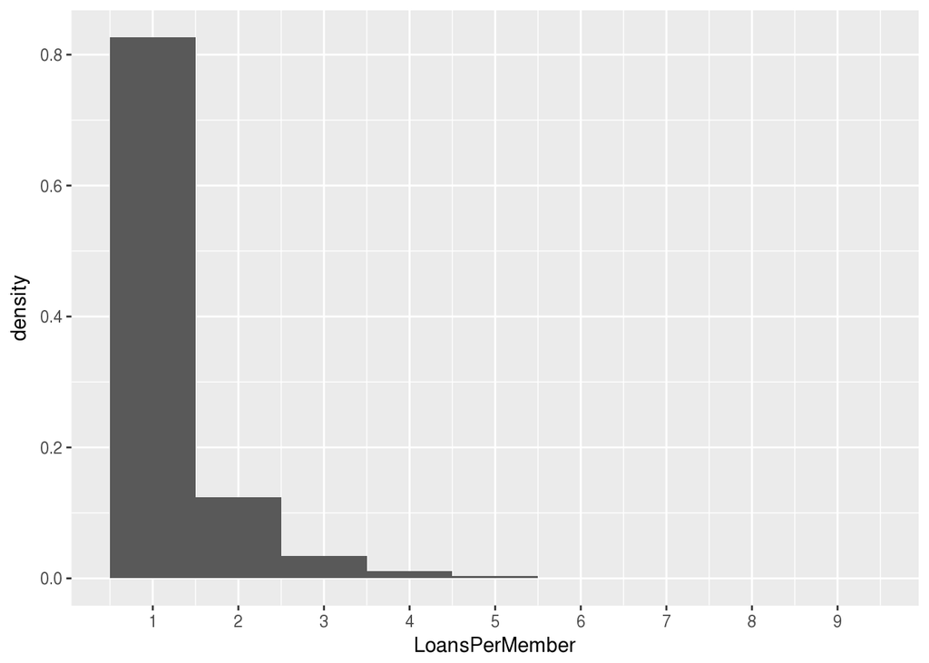

```
## # A tibble: 9 x 2
##   LoansPerMember    No
##            <int> <int>
## 1              1 75093
## 2              2 11230
## 3              3  3073
## 4              4  1022
## 5              5   310
## 6              6    74
## 7              7    21
## 8              8     7
## 9              9     1
```

Most borrowers in this data set only received one loan, but there are borrowers, who receive up to 9 loans.

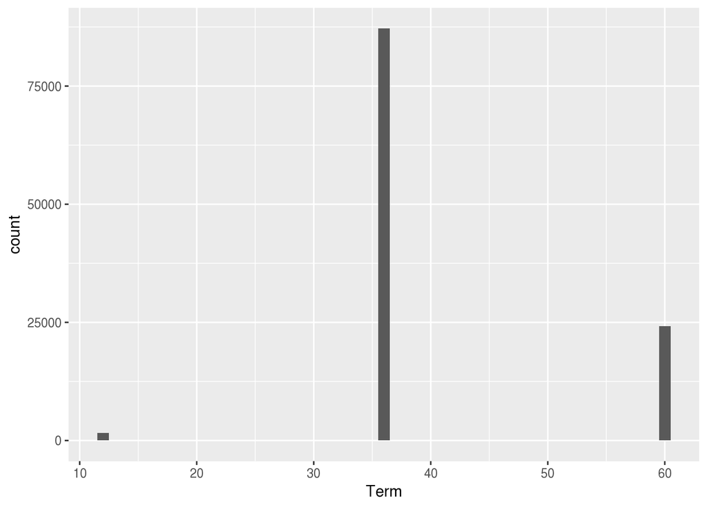

```
##
##    12    36    60
##  1614 87224 24228
```

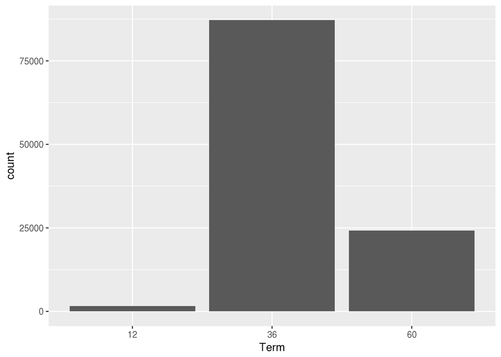

Term only has three distinct values, 12, 36, 60 months, and no missing values, so it makes sense to transform the variable into a factor. Most loans run for 36 months.

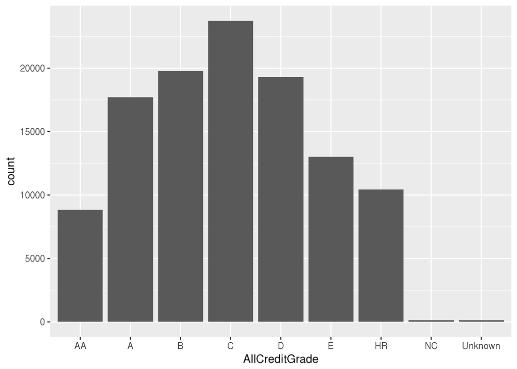

```
##
##      AA       A       B       C       D       E      HR      NC Unknown
##    8834   17705   19757   23745   19323   13005   10425     141     131
```

This is a nicely distributed variable; the extreme levels AA and HR are relatively rare, and the most frequent value is “C”, which is as expected.

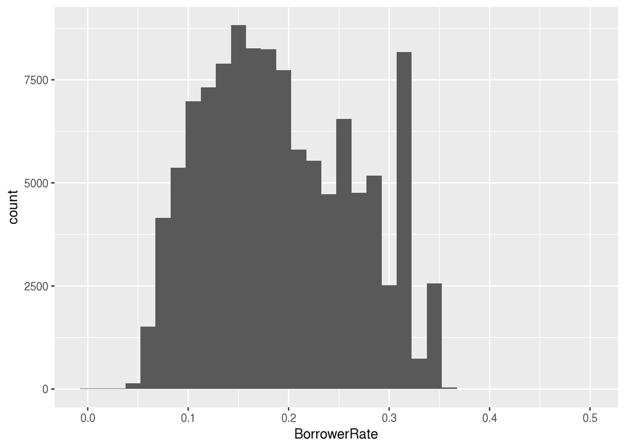

```
##    Min. 1st Qu.  Median    Mean 3rd Qu.    Max.
##  0.0000  0.1340  0.1840  0.1929  0.2506  0.4975
```

```
## [1] "Unique values:  2294"
```

```
## # A tibble: 18 x 2
##    BorrowerRate     n
##           <dbl> <int>
##  1       0.3177  3672
##  2       0.3500  1905
##  3       0.3199  1651
##  4       0.2900  1508
##  5       0.2699  1314
##  6       0.1500  1174
##  7       0.1400  1022
##  8       0.1099   928
##  9       0.2000   907
## 10       0.1800   791
## 11       0.1585   781
## 12       0.2099   776
## 13       0.1299   769
## 14       0.2599   761
## 15       0.2199   739
## 16       0.3134   720
## 17       0.1620   713
## 18       0.1899   713
```

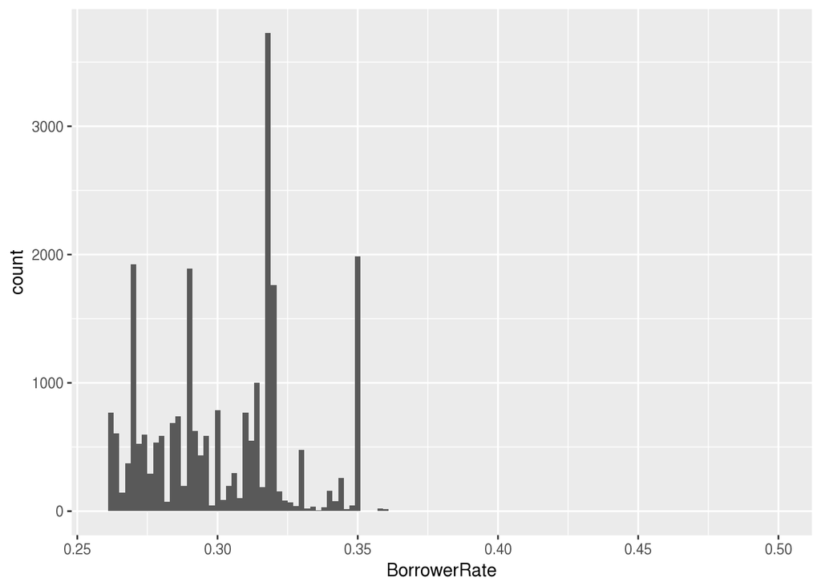

The distribution shows clear hints of rate breaks / steps. There are only about 2300 distinct values for BorrowerRate in this sample. As the aggregation shows, there are very frequent values especially above ca. 0.26. Let’s have a closer look at the upper part of the histogram. There is an overly frequent value at 0.3177, and some other spikes nearby. It should be very interesting to have a deeper look at this distribution in the bivariate and multivariate plots to better understand the determinants of this rate distribution.

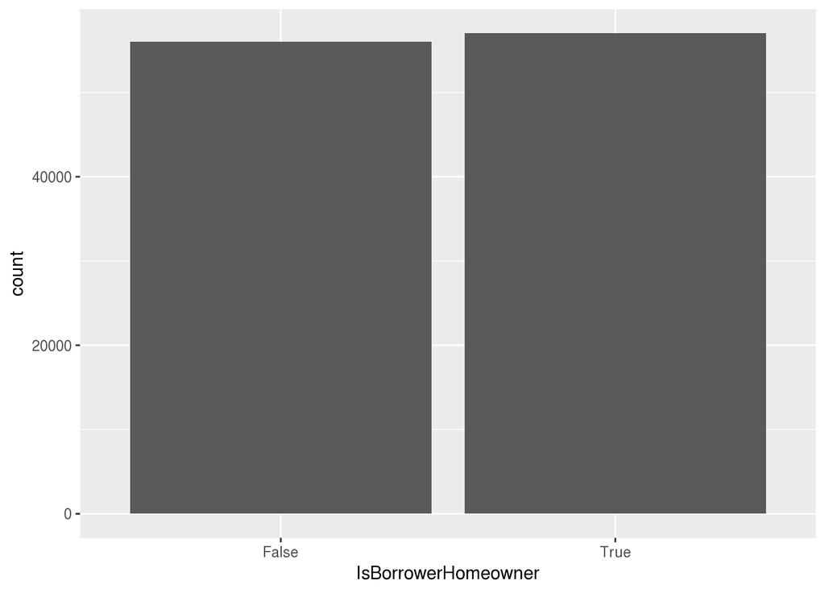

```
##
## False  True
## 56014 57052
```

There are slightly more homeowners than non-homeowners.

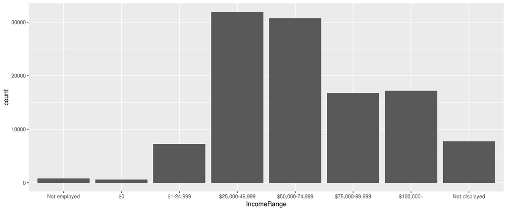

```
##
##   Not employed             $0      $1-24,999 $25,000-49,999 $50,000-74,999
##            806            621           7241          31940          30749
## $75,000-99,999      $100,000+  Not displayed
##          16780          17188           7741
```

The income range distribution looks as expected, except for the $100,000+ category, which hides the long tail of the income distribution. It is unclear, why the variable has a category “Not displayed”, which hides the income. The variable YearlyIncome could be used to retrieve the values for those loans.

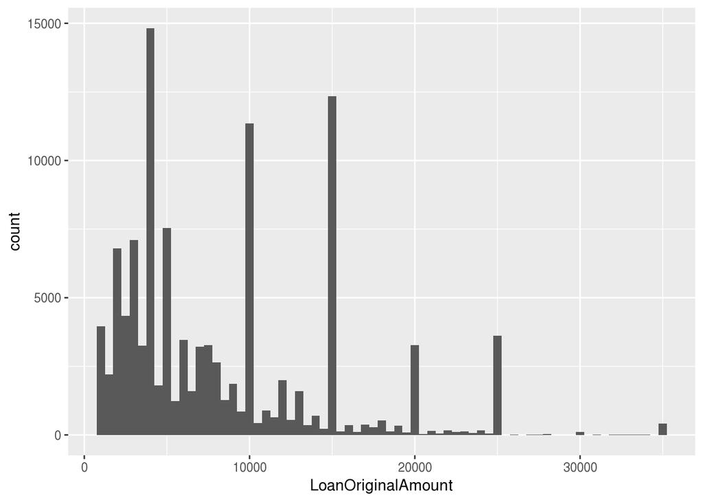

```
##    Min. 1st Qu.  Median    Mean 3rd Qu.    Max.
##    1000    4000    6300    8315   12000   35000
```

```
## [1] "Unique values:  2468"
```

```
## # A tibble: 43 x 2
##    LoanOriginalAmount     n
##                 <int> <int>
##  1               4000 14207
##  2              15000 12232
##  3              10000 10956
##  4               5000  6953
##  5               2000  6042
##  6               3000  5728
##  7              25000  3588
##  8              20000  3234
##  9               1000  3206
## 10               2500  2990
## # ... with 33 more rows
```

It is a long-tailed distribution; most of the loan amounts are below $25000. There are clearly preferred values for loan payments (e.g. $4000, $15000, $10000). Maybe these loans amounts reflect certain purchasing intentions, e.g. some consumer loan, or an auto loan with typical orders of magnitude. Overall, there are only ca. 2500 distinct loan amounts in the data set. As there are so few unique values, a log transformation of the x-axis does not reveal much more insight.

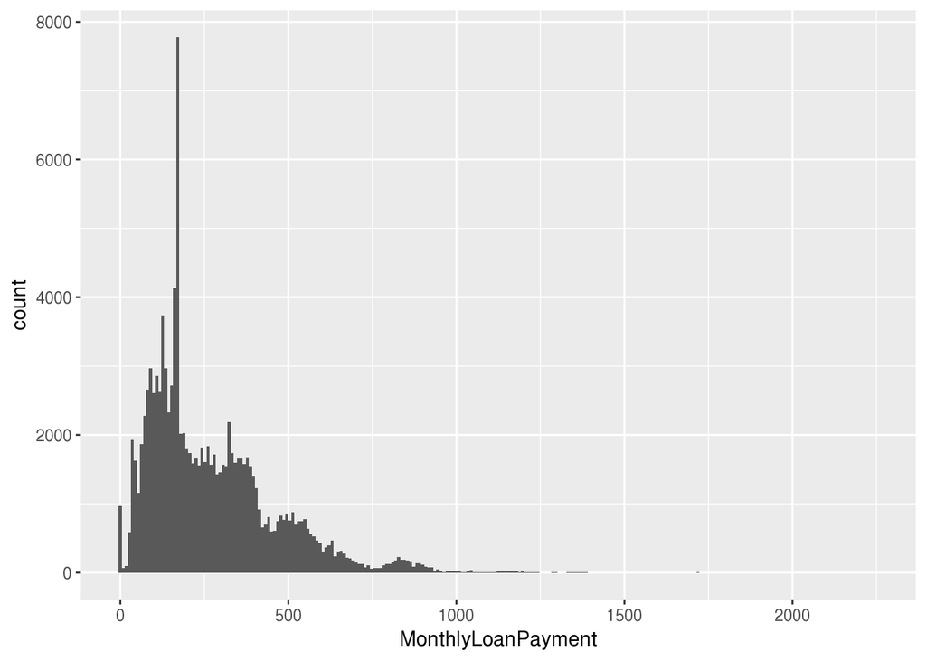

```
##    Min. 1st Qu.  Median    Mean 3rd Qu.    Max.
##     0.0   131.0   217.4   271.9   370.6  2252.0
```

```
## [1] "Unique values:  23567"
```

```
## # A tibble: 17 x 2
##    MonthlyLoanPayment     n
##                 <dbl> <int>
##  1             173.71  2423
##  2               0.00   935
##  3             172.76   530
##  4              86.85   472
##  5             174.20   460
##  6             130.28   370
##  7             163.28   285
##  8             326.62   280
##  9             136.98   277
## 10             165.15   271
## 11             161.99   265
## 12             166.54   265
## 13             169.78   255
## 14             163.56   252
## 15              45.24   248
## 16             168.17   242
## 17             168.89   227
```

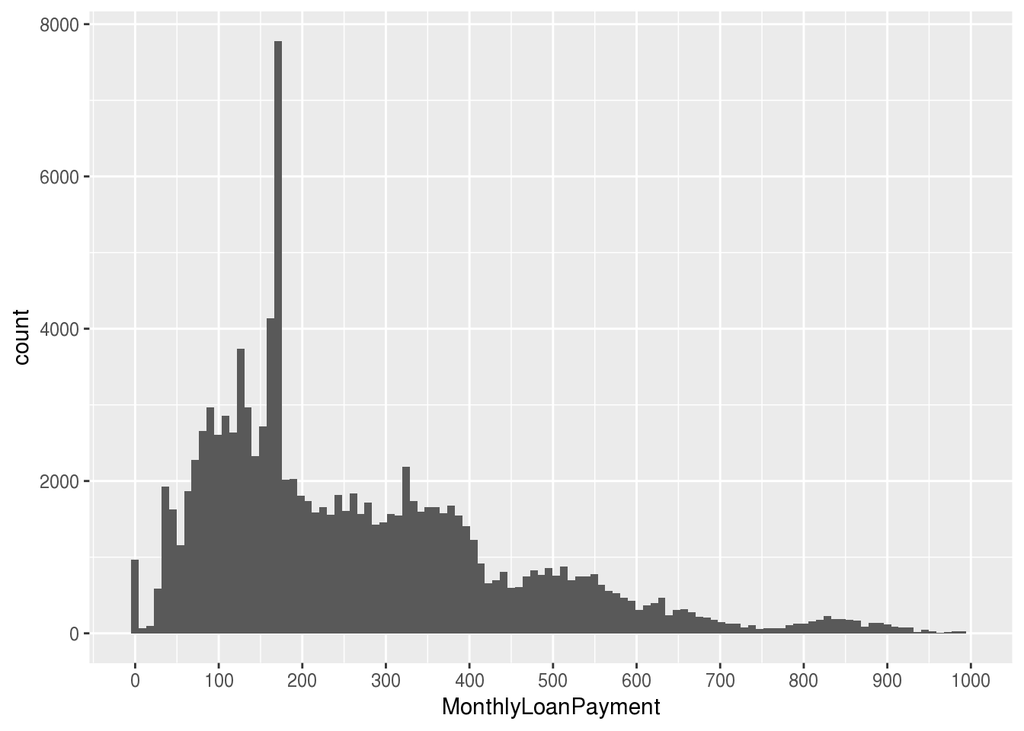

It is a long-tailed distribution; most of the monthly loan payments are below $1000. There are clearly preferred values for loan payments (e.g. $173.71, $172.76), which probably results from the limited number of values of BorrowerRate and LoanOriginalAmount. The monthly loan payment is 0 for almost 1000 loans, which is peculiar and should be connected to the loan status. The complete distribution looks like a mixture of several distributions, because of the “bumps” in the histogram; the region of [750, 1000] might serve as an example.

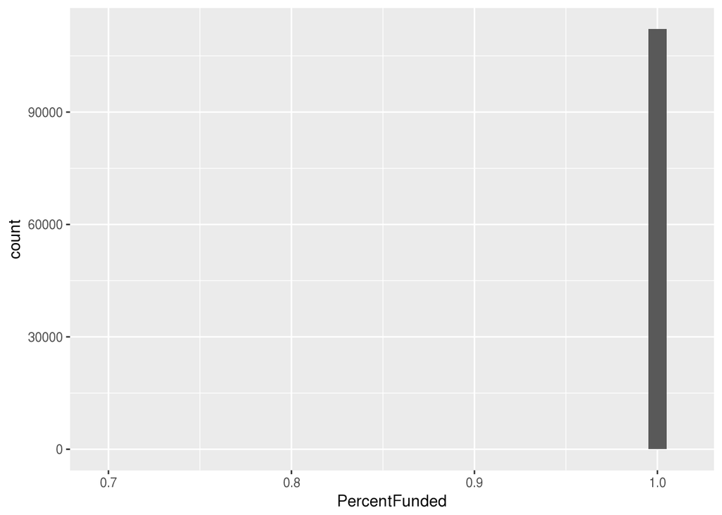

```
##    Min. 1st Qu.  Median    Mean 3rd Qu.    Max.
##  0.7000  1.0000  1.0000  0.9986  1.0000  1.0120
```

```
## [1] "Unique values:  719"
```

```
## # A tibble: 4 x 2
##   PercentFunded      n
##           <dbl>  <int>
## 1        1.0000 112196
## 2        0.9998      5
## 3        0.7000      4
## 4        0.8087      4
```

Only an absolute minority of loans are not completely funded (ca. 870). Three loans are even overfunded. This variable seem to be unfit for further investigation, as the number of underfunded loans is too small to base any inferences on.

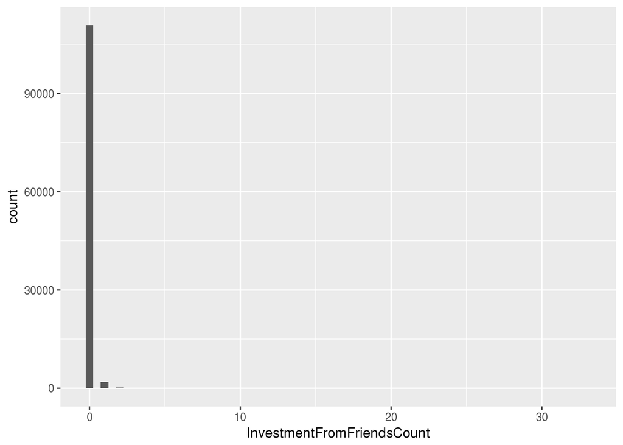

```
##     Min.  1st Qu.   Median     Mean  3rd Qu.     Max.
##  0.00000  0.00000  0.00000  0.02364  0.00000 33.00000
```

```
## [1] "Unique values:  14"
```

```
## # A tibble: 8 x 2
##   InvestmentFromFriendsCount      n
##                        <int>  <int>
## 1                          0 110935
## 2                          1   1835
## 3                          2    215
## 4                          3     40
## 5                          4     15
## 6                          5      8
## 7                          9      5
## 8                          6      4
```

Only ca. 2000 loans contain investments from friends. This variable seem to be unfit for further investigation. Even if I create a new factor variable with two levels (InvestmentFromFriendsCount>0, InvestmentFromFriendsCount ==0), the levels will be highly imbalanced.

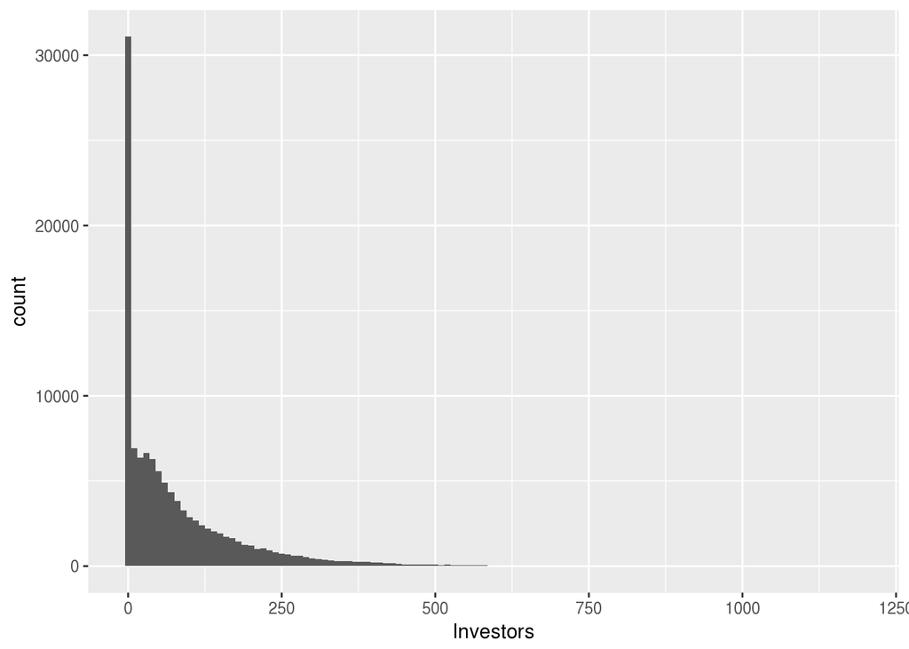

```
##    Min. 1st Qu.  Median    Mean 3rd Qu.    Max.
##    1.00    2.00   44.00   80.88  116.00 1189.00
```

```
## [1] "Unique values:  751"
```

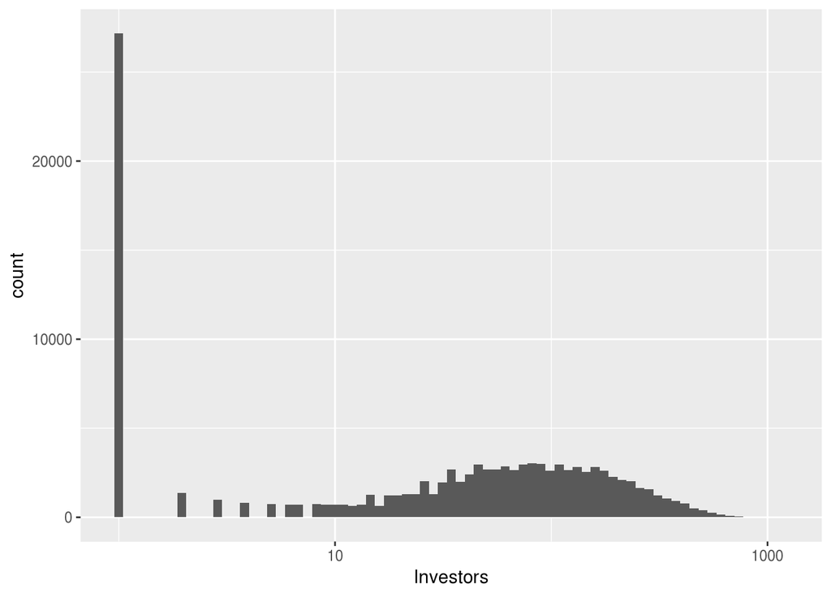

It seems there are two different distributions: one distribution with a small number of investors (<10), and one with a large number of investors [10, 1189], that is nearly log-normally distributed. The small distribution could be individual investors that are invest in single loans; the second distribution could be caused by the social network available to Prosper clients. As an example, the number of Facebook friends follows a highly skewed, long-tailed distribution (c.f. http://blog.stephenwolfram.com/2013/04/data-science-of-the-facebook-world/), resembling the one found here. So there could be two processes of funding a loan, one by (possibly unknown) individuals, and one by the social network of the borrower.

# Univariate Analysis

### What is the structure of your dataset?

The data set was last updated on 03/11/2014. This data set contains 113937 loans with 81 variables on each loan, including loan amount, borrower rate (or interest rate), current loan status, borrower income, borrower employment status, borrower credit history, and the latest payment information. Some variables are transformed to factors for easier analysis. The analysis includes 14 variables (plus the variable MemberKey which is used for borrower identification).

The following variables are ordered factors:

- AllCreditGrade: “AA”, “A”,“B”, “C”,“D”,“E”,“HR”, “NC”, “Unknown” (from best to worst)
- IncomeRange: “Not employed”, $0“,”$1-24,999“,”$25,000-49,999“,”$50,000-74,999“,”$75,000-99,999“,”$100,000+“,”Not displayed"
- Term: 12, 36, 60 Months

The following variables are unordered factors:

- LoanStatus.Simple: Cancelled, Chargedoff, Completed, Current, Defaulted, FinalPaymentInProgress, Past Due
- IsBorrowerHomeowner: False, True

The data set is focused on Prosper loans, which means that it only contains investors and borrowers, that have successfully secured a loan. The data set does not reveal, how many listings were unsuccessful. So it is impossible to find out the determinants of loan origination, as the properties of declined loans and their borrowers are not available. In this respect, this is a biased, censored data set. So the best possible result is a better understanding of the common properties of existing loans, but not a better understanding of the whole loan lifecycle.

### What is/are the main feature(s) of interest in your dataset?

As I am interested in the determinants of the loan status, I would like to take a closer look at the main variables Credit Grade, the borrower rate and the StatedMonthlyIncome / YearlyIncome.

### What other features in the dataset do you think will help support your investigation into your feature(s) of interest?

I think, home ownership, social pressure (no. of friend investors) and LoanOriginalAmount might also play a role in explaining the loan status. A longitudinal data analysis might also be interesting.

### Did you create any new variables from existing variables in the dataset?

I created the YearlyIncome as 12 times the StatedMonthlyIncome; the new variable can be used to assess the data consistency with the IncomeRange variable.

I also created the AllCreditGrade variable, as a combination of the CreditGrade and the ProsperRating..Alpha. variables, as both variables measure the same concept, but have complementary validity timespans. By combining the variables, the missing values of both variables can be almost completely eliminated.

LoanSetupTime and LoanStatus.Simple are also new variables, please see above for a description.

### Of the features you investigated, were there any unusual distributions? Did you perform any operations on the data to tidy, adjust, or change the form of the data? If so, why did you do this?

I log-transformed the right-skewed variables Investors, StatedMonthlyIncome and LoanSetupTime. Investors and StatedMonthlyIncome seem to be partly log-normally distributed, and the underlying real-world processes seem to support this assumption.

MonthlyLoanPayment is dependent on the BorrowerRate and the LoanOriginalAmount; as BorrowerRate and LoanOriginalAmount show highly preferred threshold values. The same threshold structure is again visible in the MonthlyLoanPayment variable .

871 duplicate records are removed from the original data set.

# Bivariate Plots Section

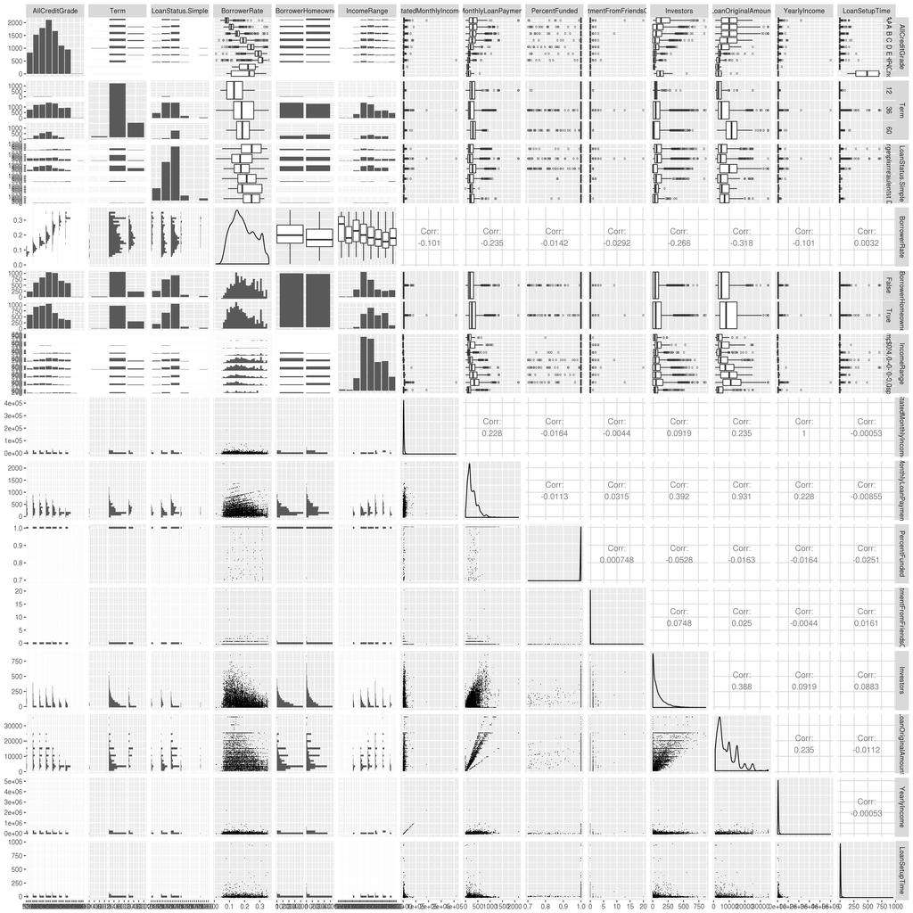

The observations from the GGpairs plot focus especially on interesting, bivariate plots of a numeric variable and a factor variable. The following variable combinations will be analyzed more deeply with individual plots:

- AllCreditGrade vs. BorrowerRate
- AllCreditGrade vs. StatedMonthlyIncome
- AllCreditGrade vs. Investors
- LoanStatus.Simple vs. LoanOriginalAmount
- LoanStatus.Simple vs. BorrowerRate
- LoanStatus.Simple vs. AllCreditGrade
- LoanStatus.Simple vs. Investors

To better assess the linear correlations among the numeric variables, a correlation matrix is used.

```
##                            BorrowerRate StatedMonthlyIncome
## BorrowerRate                      1.000              -0.139
## StatedMonthlyIncome              -0.139               1.000
## MonthlyLoanPayment               -0.244               0.300
## PercentFunded                    -0.024              -0.026
## InvestmentFromFriendsCount       -0.038              -0.015
## Investors                        -0.280               0.125
## LoanOriginalAmount               -0.324               0.307
## LoanSetupTime                    -0.018               0.002
## DebtToIncomeRatio                 0.063              -0.123
##                            MonthlyLoanPayment PercentFunded
## BorrowerRate                           -0.244        -0.024
## StatedMonthlyIncome                     0.300        -0.026
## MonthlyLoanPayment                      1.000        -0.011
## PercentFunded                          -0.011         1.000
## InvestmentFromFriendsCount             -0.007         0.002
## Investors                               0.391        -0.051
## LoanOriginalAmount                      0.933        -0.013
## LoanSetupTime                          -0.008        -0.030
## DebtToIncomeRatio                       0.028         0.002
##                            InvestmentFromFriendsCount Investors
## BorrowerRate                                   -0.038    -0.280
## StatedMonthlyIncome                            -0.015     0.125
## MonthlyLoanPayment                             -0.007     0.391
## PercentFunded                                   0.002    -0.051
## InvestmentFromFriendsCount                      1.000     0.065
## Investors                                       0.065     1.000
## LoanOriginalAmount                             -0.012     0.382
## LoanSetupTime                                   0.017     0.091
## DebtToIncomeRatio                               0.034     0.004
##                            LoanOriginalAmount LoanSetupTime
## BorrowerRate                           -0.324        -0.018
## StatedMonthlyIncome                     0.307         0.002
## MonthlyLoanPayment                      0.933        -0.008
## PercentFunded                          -0.013        -0.030
## InvestmentFromFriendsCount             -0.012         0.017
## Investors                               0.382         0.091
## LoanOriginalAmount                      1.000        -0.011
## LoanSetupTime                          -0.011         1.000
## DebtToIncomeRatio                       0.010        -0.003
##                            DebtToIncomeRatio
## BorrowerRate                           0.063
## StatedMonthlyIncome                   -0.123
## MonthlyLoanPayment                     0.028
## PercentFunded                          0.002
## InvestmentFromFriendsCount             0.034
## Investors                              0.004
## LoanOriginalAmount                     0.010
## LoanSetupTime                         -0.003
## DebtToIncomeRatio                      1.000
```

The above correlations matrix reveals some noteworthy correlations:

- LoanOriginalAmount and BorrowerRate are weakly negatively correlated. An additional analysis is needed for this counterintuitive result. Usually, you would think that a higher LoanOriginalAmount causes a higher BorrowerRate because of the higher risk, but in this data set, a higher loan amount is associated with a lower borrower rate.
- LoanOriginalAmount and StatedMonthlyIncome are weakly positively correlated, which makes sense: the more you earn, the easier it is to get a loan (at least for those borrowers that manage to get a loan at all).
- Investors and MonthlyLoanPayment / LoanOriginalAmount are weakly positively correlated, which seems obvious.
- Investors and BorrowerRate are weakly negatively correlated. An additional analysis is needed for this counterintuitive result. Usually, you would think that a higher BorrowerRate attracts more Investors.

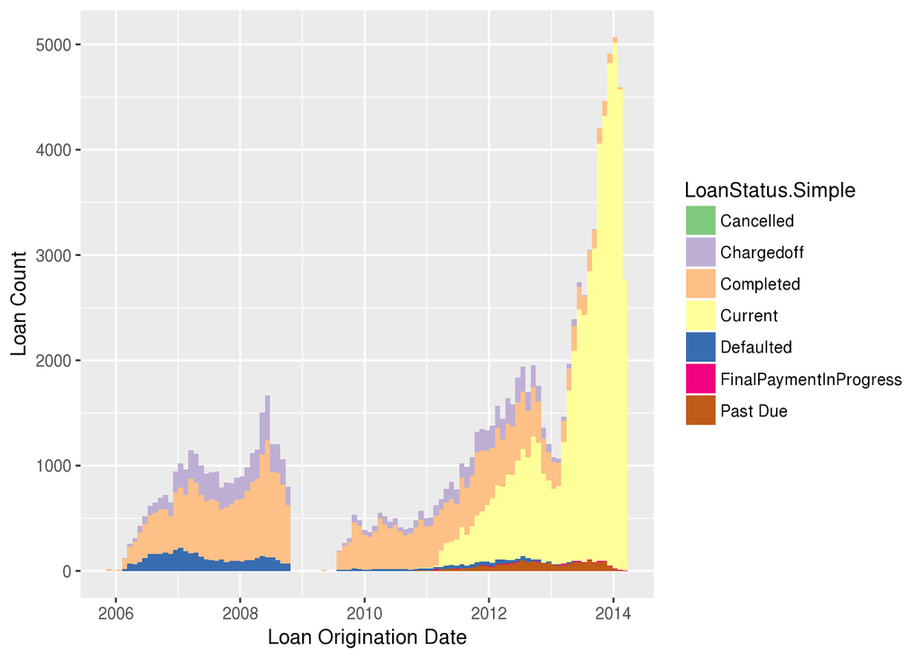

The above plot shows the number of loans by LoanOriginationDate, using LoanStatus as fill color. As most loans run 3 years or more, the proportion of loans with status current becomes dominant from 2011 on. These loans were originated and are still running or are past due. For most of them, their final loan status is unknown. Only loans older than 2011 have certainly completed their full lifecycle and are either completed, defaulted or chargedoff.

It is definitely fascinating, how Prosper expanded its business from 2013 on.

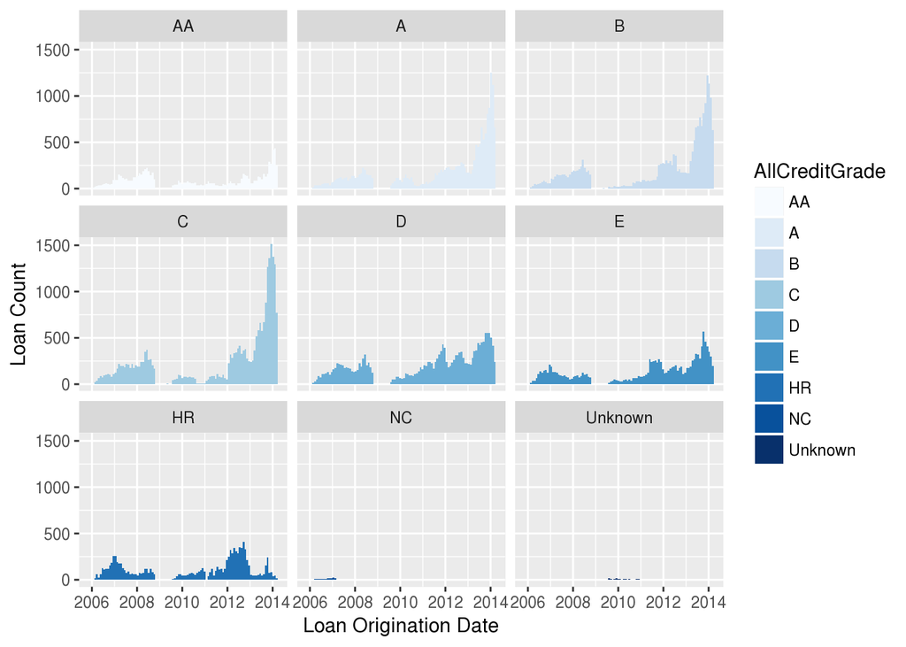

The above plot shows the number of loans originated over time and split up by credit grade. The overall number of loans in each credit grade facet follows the distribution of AllCreditGrade, so the level of counts per grade should not be surprising. However, the temporal distribution is pretty different among the credit grades. Something interesting must have happened for the “C” credit grade - it seems, Prosper originated almost no loans in the second half of 2010, but ramped up loan origination massively from 2012 on. The loan origination to HR credit grade was reduced, as it seems; from 2013 on, HR loans do not participate in the overall uptake of the loan business, but only show a very small peak, that disappears by 2014. Another explanation would be a redefinition of the “HR” credit grade, such that more borrowers would be classified with a better credit grade. It should be very interesting to add the third variable LoanStatus.Simple to this plot, in order to see whether loans with a low credit grade also show a bad loan status; this is investigated in the multivariate plots section.

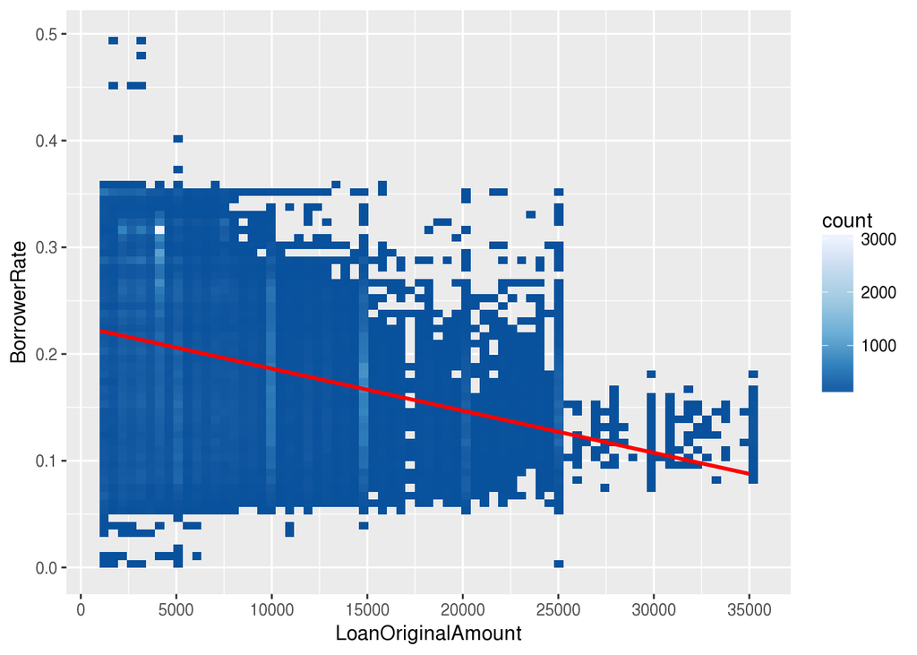

Normally, this plot should be a scatter plot using geom_point(), but a 2D heatmap of bin counts was chosen to eliminate overplotting. This plot has a clear and unique peak at around $4000 loan amount and 0.32 rate, which are the combined peaks of the individual distributions. The smoothing function is a linear regression and shows the negative correlation of the two variables. Maybe the credit grade can explain this relationship; this is investigated in the multivariate plots section.

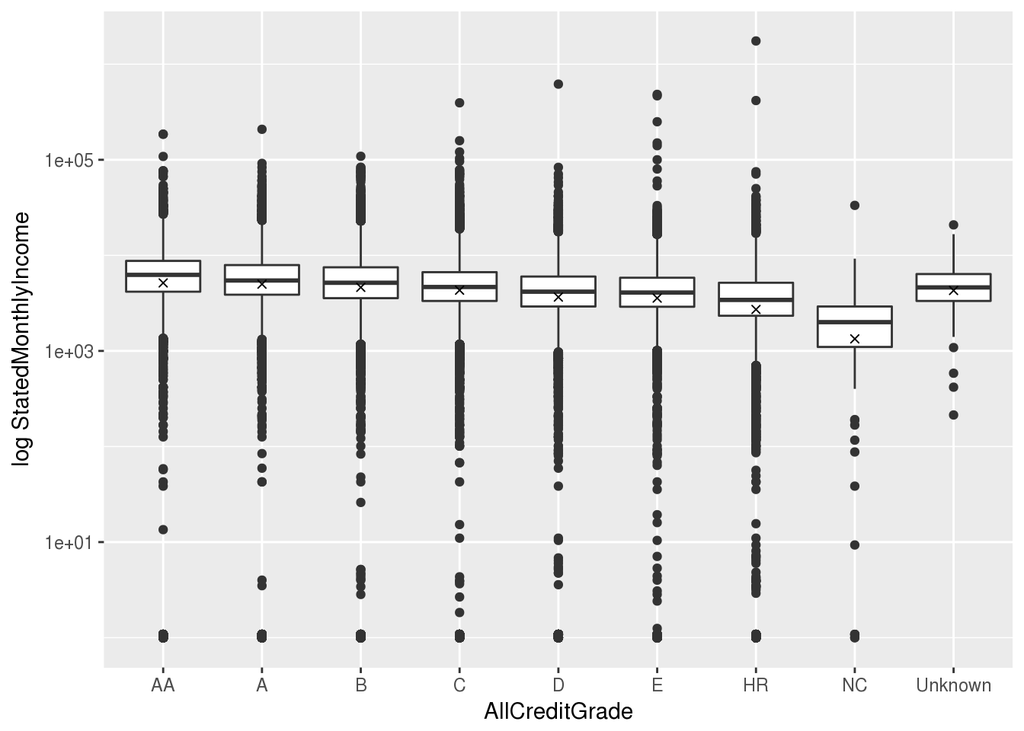

```
## pr_df$AllCreditGrade: AA
##    Min. 1st Qu.  Median    Mean 3rd Qu.    Max.
##       0    4167    6250    7238    8750  185100
## --------------------------------------------------------
## pr_df$AllCreditGrade: A
##    Min. 1st Qu.  Median    Mean 3rd Qu.    Max.
##       0    3877    5458    6470    7917  208300
## --------------------------------------------------------
## pr_df$AllCreditGrade: B
##    Min. 1st Qu.  Median    Mean 3rd Qu.    Max.
##       0    3566    5167    6130    7500  108800
## --------------------------------------------------------
## pr_df$AllCreditGrade: C
##    Min. 1st Qu.  Median    Mean 3rd Qu.    Max.
##       0    3333    4667    5538    6667  394400
## --------------------------------------------------------
## pr_df$AllCreditGrade: D
##    Min. 1st Qu.  Median    Mean 3rd Qu.    Max.
##       0    2917    4167    4876    6000  618500
## --------------------------------------------------------
## pr_df$AllCreditGrade: E
##    Min. 1st Qu.  Median    Mean 3rd Qu.    Max.
##       0    2900    4083    4805    5833  483300
## --------------------------------------------------------
## pr_df$AllCreditGrade: HR
##    Min. 1st Qu.  Median    Mean 3rd Qu.    Max.
##       0    2333    3417    4310    5167 1750000
## --------------------------------------------------------
## pr_df$AllCreditGrade: NC
##    Min. 1st Qu.  Median    Mean 3rd Qu.    Max.
##       0    1100    2000    2437    2917   33330
## --------------------------------------------------------
## pr_df$AllCreditGrade: Unknown
##    Min. 1st Qu.  Median    Mean 3rd Qu.    Max.
##   212.8  3333.0  4617.0  5111.0  6375.0 20830.0
```

The results of this plot are not surprising: the credit grade is directly linked to the stated monthly income. Both the mean and the median of the income rise with the credit grade. The only exception are borrowers with unknown credit grade, whose income places them somewhere between a “C” and a “D” credit grade. It is interesting to see, that even borrowers with a good credit grade report a monthly income of $0, which seems unrealistic. Maybe this was a deliberate misinformation by the borrowers in order to avoid giving their true income, or 0 is used as a replacement for a null value.

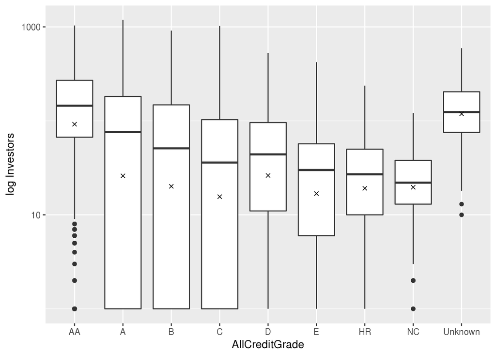

```
## pr_df$AllCreditGrade: AA
##    Min. 1st Qu.  Median    Mean 3rd Qu.    Max.
##     1.0    67.0   145.0   182.7   270.0  1035.0
## --------------------------------------------------------
## pr_df$AllCreditGrade: A
##    Min. 1st Qu.  Median    Mean 3rd Qu.    Max.
##     1.0     1.0    76.0   114.8   182.0  1189.0
## --------------------------------------------------------
## pr_df$AllCreditGrade: B
##    Min. 1st Qu.  Median    Mean 3rd Qu.    Max.
##    1.00    1.00   51.00   92.04  148.00  913.00
## --------------------------------------------------------
## pr_df$AllCreditGrade: C
##    Min. 1st Qu.  Median    Mean 3rd Qu.    Max.
##    1.00    1.00   36.00   65.91  103.00 1024.00
## --------------------------------------------------------
## pr_df$AllCreditGrade: D
##    Min. 1st Qu.  Median    Mean 3rd Qu.    Max.
##    1.00   11.00   44.00   64.04   96.00  528.00
## --------------------------------------------------------
## pr_df$AllCreditGrade: E
##    Min. 1st Qu.  Median    Mean 3rd Qu.    Max.
##    1.00    6.00   30.00   38.51   57.00  422.00
## --------------------------------------------------------
## pr_df$AllCreditGrade: HR
##    Min. 1st Qu.  Median    Mean 3rd Qu.    Max.
##    1.00   10.00   27.00   33.72   50.00  237.00
## --------------------------------------------------------
## pr_df$AllCreditGrade: NC
##    Min. 1st Qu.  Median    Mean 3rd Qu.    Max.
##    1.00   13.00   22.00   28.62   38.00  121.00
## --------------------------------------------------------
## pr_df$AllCreditGrade: Unknown
##    Min. 1st Qu.  Median    Mean 3rd Qu.    Max.
##    10.0    75.5   124.0   155.5   204.0   594.0
```

This plot shows an unsurprising result: in most cases, the number of investors is directly related to the credit grade of the borrower. For the “C” and “D” grade, this relationship does not hold for the median, but for the mean.

This observation leads to a hypothesis: maybe the higher number of investors in good credit grades is caused by a higher loan amount in those credit grades, i.e. maybe the number of investors is driven by the loan amount? Let’s find out in the next plot.

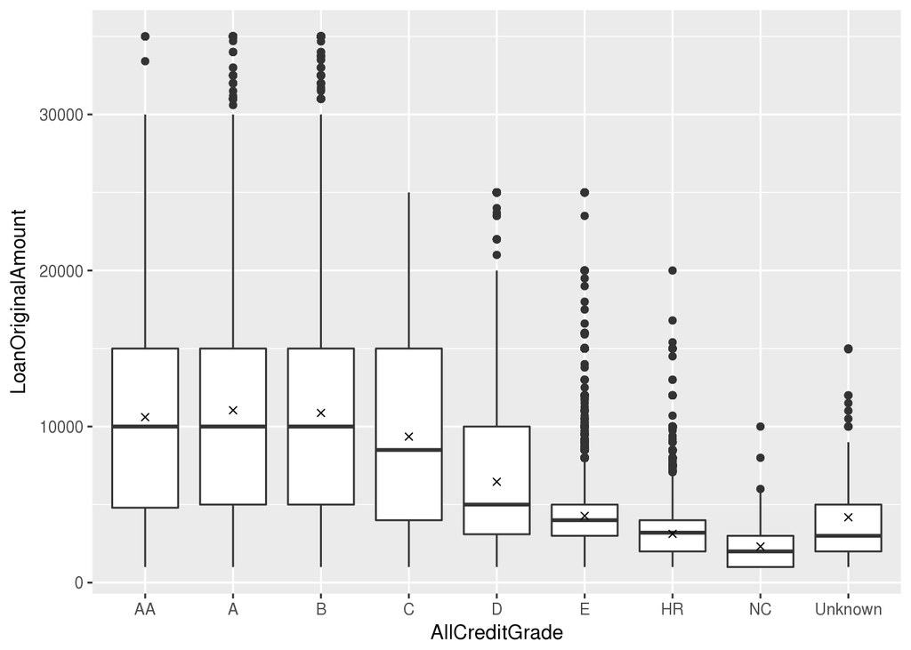

```
## pr_df$AllCreditGrade: AA
##    Min. 1st Qu.  Median    Mean 3rd Qu.    Max.
##    1000    4800   10000   10600   15000   35000
## --------------------------------------------------------
## pr_df$AllCreditGrade: A
##    Min. 1st Qu.  Median    Mean 3rd Qu.    Max.
##    1000    5000   10000   11040   15000   35000
## --------------------------------------------------------
## pr_df$AllCreditGrade: B
##    Min. 1st Qu.  Median    Mean 3rd Qu.    Max.
##    1000    5000   10000   10870   15000   35000
## --------------------------------------------------------
## pr_df$AllCreditGrade: C
##    Min. 1st Qu.  Median    Mean 3rd Qu.    Max.
##    1000    4000    8500    9357   15000   25000
## --------------------------------------------------------
## pr_df$AllCreditGrade: D
##    Min. 1st Qu.  Median    Mean 3rd Qu.    Max.
##    1000    3100    5000    6464   10000   25000
## --------------------------------------------------------
## pr_df$AllCreditGrade: E
##    Min. 1st Qu.  Median    Mean 3rd Qu.    Max.
##    1000    3000    4000    4276    4999   25000
## --------------------------------------------------------
## pr_df$AllCreditGrade: HR
##    Min. 1st Qu.  Median    Mean 3rd Qu.    Max.
##    1000    2000    3200    3123    4000   20000
## --------------------------------------------------------
## pr_df$AllCreditGrade: NC
##    Min. 1st Qu.  Median    Mean 3rd Qu.    Max.
##    1000    1000    2000    2316    3000   10000
## --------------------------------------------------------
## pr_df$AllCreditGrade: Unknown
##    Min. 1st Qu.  Median    Mean 3rd Qu.    Max.
##    1000    2000    3000    4187    5000   15000
```

As far as I can tell from this dataset, the loan amount in credit grades “AA”, “A”, “B” is pretty much comparable, so the hypothesis is probably wrong, which leads to the conclusion that the number of investors is driven by the credit grade of the borrower.

Interestingly, the loan amount in the credit grades “C” and worse is declining on average; these borrowers obviously receive less money. Also, the fact is noteworthy, that the maximum loan amount seems to be tied to the credit grade. Borrowers with grade “D” and “E” are pretty unlikely to receive a $25000 loan, whereas borrowers with a lower grade are relegated to even lower maximum amounts.

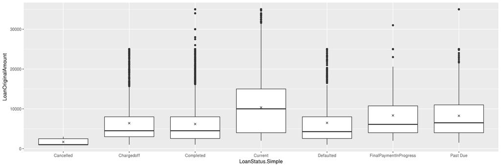

```
## pr_df$LoanStatus.Simple: Cancelled
##    Min. 1st Qu.  Median    Mean 3rd Qu.    Max.
##    1000    1000    1000    1700    2500    3000
## --------------------------------------------------------
## pr_df$LoanStatus.Simple: Chargedoff
##    Min. 1st Qu.  Median    Mean 3rd Qu.    Max.
##    1000    3000    4500    6399    8000   25000
## --------------------------------------------------------
## pr_df$LoanStatus.Simple: Completed
##    Min. 1st Qu.  Median    Mean 3rd Qu.    Max.
##    1000    2550    4500    6188    8000   35000
## --------------------------------------------------------
## pr_df$LoanStatus.Simple: Current
##    Min. 1st Qu.  Median    Mean 3rd Qu.    Max.
##    2000    4000   10000   10350   15000   35000
## --------------------------------------------------------
## pr_df$LoanStatus.Simple: Defaulted
##    Min. 1st Qu.  Median    Mean 3rd Qu.    Max.
##    1000    2550    4275    6487    8000   25000
## --------------------------------------------------------
## pr_df$LoanStatus.Simple: FinalPaymentInProgress
##    Min. 1st Qu.  Median    Mean 3rd Qu.    Max.
##    2000    4000    6100    8345   10750   31000
## --------------------------------------------------------
## pr_df$LoanStatus.Simple: Past Due
##    Min. 1st Qu.  Median    Mean 3rd Qu.    Max.
##    1500    4000    6500    8255   11000   35000
```

The dataset does not reveal any strong relationship between the loan status and the loan amount. The lost loans (status “Chargedoff”, “Defaulted”) share similar properties, only “Past Due” loans tend to be larger.

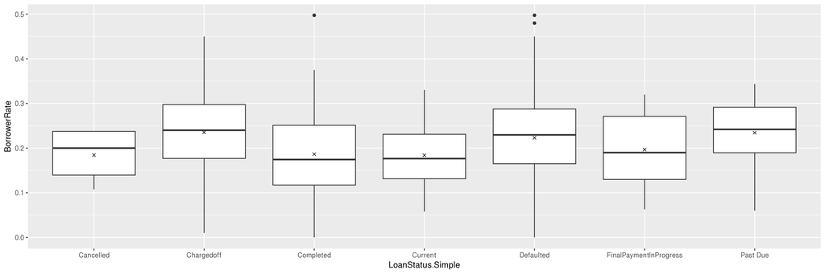

```
## pr_df$LoanStatus.Simple: Cancelled
##    Min. 1st Qu.  Median    Mean 3rd Qu.    Max.
##  0.1075  0.1395  0.2000  0.1844  0.2375  0.2375
## --------------------------------------------------------
## pr_df$LoanStatus.Simple: Chargedoff
##    Min. 1st Qu.  Median    Mean 3rd Qu.    Max.
##  0.0100  0.1769  0.2400  0.2354  0.2975  0.4500
## --------------------------------------------------------
## pr_df$LoanStatus.Simple: Completed
##    Min. 1st Qu.  Median    Mean 3rd Qu.    Max.
##  0.0000  0.1173  0.1744  0.1864  0.2511  0.4975
## --------------------------------------------------------
## pr_df$LoanStatus.Simple: Current
##    Min. 1st Qu.  Median    Mean 3rd Qu.    Max.
##  0.0577  0.1314  0.1765  0.1840  0.2310  0.3304
## --------------------------------------------------------
## pr_df$LoanStatus.Simple: Defaulted
##    Min. 1st Qu.  Median    Mean 3rd Qu.    Max.
##  0.0000  0.1650  0.2296  0.2231  0.2875  0.4975
## --------------------------------------------------------
## pr_df$LoanStatus.Simple: FinalPaymentInProgress
##    Min. 1st Qu.  Median    Mean 3rd Qu.    Max.
##  0.0629  0.1299  0.1899  0.1967  0.2712  0.3199
## --------------------------------------------------------
## pr_df$LoanStatus.Simple: Past Due
##    Min. 1st Qu.  Median    Mean 3rd Qu.    Max.
##  0.0599  0.1896  0.2419  0.2345  0.2916  0.3435
```

The lost loans (status “Chargedoff”, “Defaulted”) and the troubled ones (status “Past Due”) show an elevated borrower rate, as compared to the loans running smoothly. “Cancelled” is a separate category, as the loan did not run its normal course.

This observation leads to the question, if the borrower rate is inversely related to the credit grade of the borrower (i.e. the better the grade, the lower the rate). So, a bad borrower would also cause troubled loans. Let’s find out in the next plot.

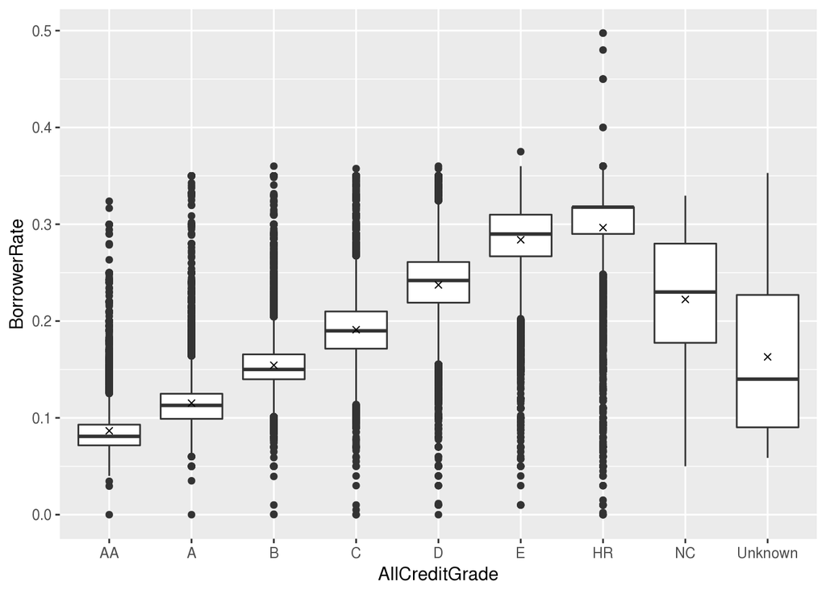

```
## pr_df$AllCreditGrade: AA
##    Min. 1st Qu.  Median    Mean 3rd Qu.    Max.
## 0.00000 0.07160 0.08090 0.08666 0.09300 0.32380
## --------------------------------------------------------
## pr_df$AllCreditGrade: A
##    Min. 1st Qu.  Median    Mean 3rd Qu.    Max.
##  0.0000  0.0990  0.1129  0.1152  0.1249  0.3500
## --------------------------------------------------------
## pr_df$AllCreditGrade: B
##    Min. 1st Qu.  Median    Mean 3rd Qu.    Max.
##  0.0001  0.1399  0.1500  0.1544  0.1656  0.3600
## --------------------------------------------------------
## pr_df$AllCreditGrade: C
##    Min. 1st Qu.  Median    Mean 3rd Qu.    Max.
##  0.0000  0.1715  0.1899  0.1911  0.2099  0.3575
## --------------------------------------------------------
## pr_df$AllCreditGrade: D
##    Min. 1st Qu.  Median    Mean 3rd Qu.    Max.
##  0.0000  0.2190  0.2419  0.2373  0.2610  0.3600
## --------------------------------------------------------
## pr_df$AllCreditGrade: E
##    Min. 1st Qu.  Median    Mean 3rd Qu.    Max.
##  0.0100  0.2669  0.2899  0.2840  0.3099  0.3750
## --------------------------------------------------------
## pr_df$AllCreditGrade: HR
##    Min. 1st Qu.  Median    Mean 3rd Qu.    Max.
##  0.0000  0.2900  0.3177  0.2965  0.3177  0.4975
## --------------------------------------------------------
## pr_df$AllCreditGrade: NC
##    Min. 1st Qu.  Median    Mean 3rd Qu.    Max.
##  0.0500  0.1775  0.2300  0.2224  0.2800  0.3295
## --------------------------------------------------------
## pr_df$AllCreditGrade: Unknown
##    Min. 1st Qu.  Median    Mean 3rd Qu.    Max.
## 0.05870 0.09025 0.14000 0.16300 0.22700 0.35300
```

Although the plot shows a lot of outliers, the message is clear: the credit grade is directly related to the rate, except for the “NC” grade, which receives an average rate.

This also provides a partial answer to the question: borrowers with a bad credit grade need to pay more for their loan, and these loans are also more prone to cause trouble.

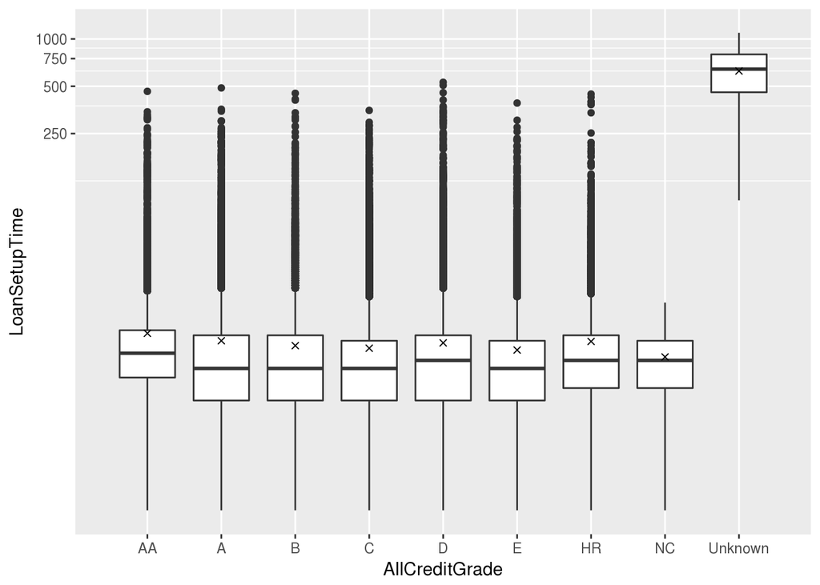

```
## pr_df$AllCreditGrade: AA
##    Min. 1st Qu.  Median    Mean 3rd Qu.    Max.
##    1.00    7.00   10.00   13.38   14.00  464.00
## --------------------------------------------------------
## pr_df$AllCreditGrade: A
##    Min. 1st Qu.  Median    Mean 3rd Qu.    Max.
##       1       5       8      12      13     488
## --------------------------------------------------------
## pr_df$AllCreditGrade: B
##    Min. 1st Qu.  Median    Mean 3rd Qu.    Max.
##    1.00    5.00    8.00   11.17   13.00  451.00
## --------------------------------------------------------
## pr_df$AllCreditGrade: C
##    Min. 1st Qu.  Median    Mean 3rd Qu.    Max.
##    1.00    5.00    8.00   10.76   12.00  351.00
## --------------------------------------------------------
## pr_df$AllCreditGrade: D
##    Min. 1st Qu.  Median    Mean 3rd Qu.    Max.
##    1.00    5.00    9.00   11.63   13.00  530.00
## --------------------------------------------------------
## pr_df$AllCreditGrade: E
##    Min. 1st Qu.  Median    Mean 3rd Qu.    Max.
##    1.00    5.00    8.00   10.47   12.00  391.00
## --------------------------------------------------------
## pr_df$AllCreditGrade: HR
##    Min. 1st Qu.  Median    Mean 3rd Qu.    Max.
##    1.00    6.00    9.00   11.88   13.00  446.00
## --------------------------------------------------------
## pr_df$AllCreditGrade: NC
##    Min. 1st Qu.  Median    Mean 3rd Qu.    Max.
##   1.000   6.000   9.000   9.468  12.000  21.000
## --------------------------------------------------------
## pr_df$AllCreditGrade: Unknown
##    Min. 1st Qu.  Median    Mean 3rd Qu.    Max.
##    94.0   458.0   643.0   625.3   798.0  1095.0
```

There seems to be no discernible difference among the loan setup times per credit grade, except for the unknown credit grade. Maybe, the credit grade determines the duration of the loan?

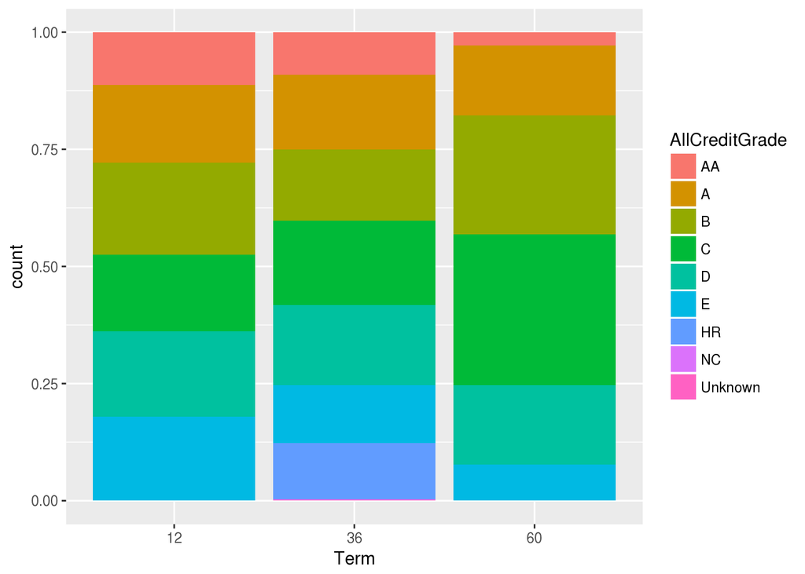

```
## pr_df$Term: 12
##      AA       A       B       C       D       E      HR      NC Unknown
##     181     269     316     264     295     288       0       0       1
## --------------------------------------------------------
## pr_df$Term: 36
##      AA       A       B       C       D       E      HR      NC Unknown
##    7955   13843   13277   15696   14911   10846   10425     141     130
## --------------------------------------------------------
## pr_df$Term: 60
##      AA       A       B       C       D       E      HR      NC Unknown
##     698    3593    6164    7785    4117    1871       0       0       0
```

If you break out the relative proportions for each term value, there are few differences between the three term values, i.e. borrowers can pick their term value independent of their credit grade. There is one notable exception: the dataset only contains loans from borrowers with “HR” credit grade that run for 36 months, not longer, not shorter. There might be a restriction in place for those borrowers.

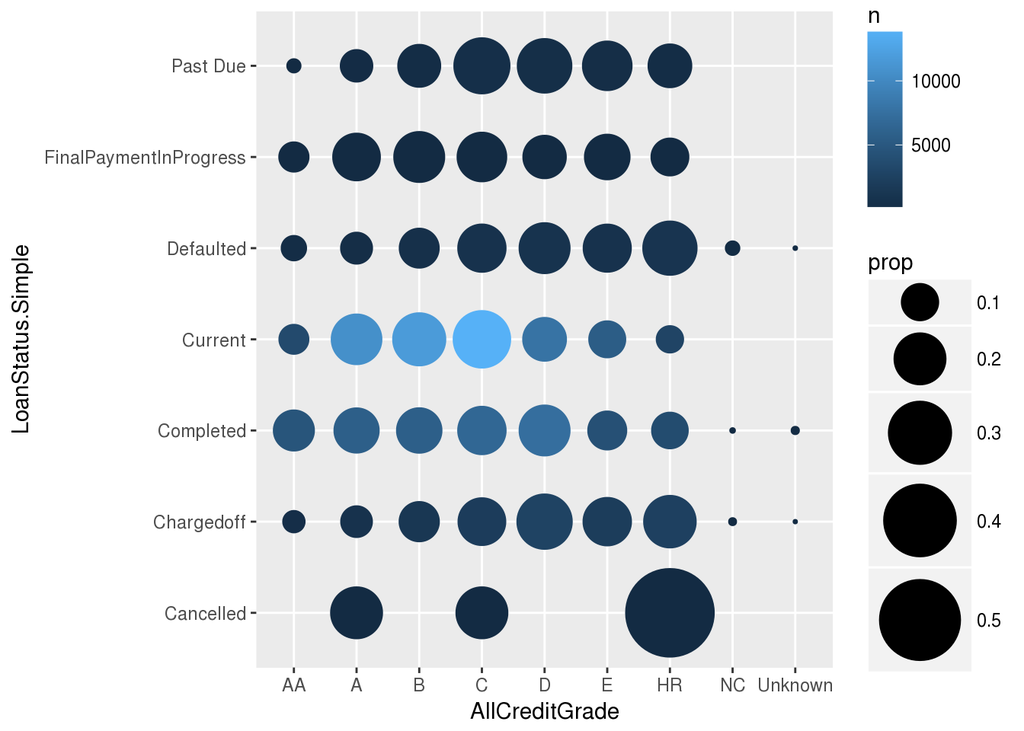

```
## pr_df$AllCreditGrade: AA
##              Cancelled             Chargedoff              Completed
##                      0                    402                   4667
##                Current              Defaulted FinalPaymentInProgress
##                   3506                    221                     13
##               Past Due
##                     25
## --------------------------------------------------------
## pr_df$AllCreditGrade: A
##              Cancelled             Chargedoff              Completed
##                      1                    852                   5707
##                Current              Defaulted FinalPaymentInProgress
##                  10595                    362                     34
##               Past Due
##                    154
## --------------------------------------------------------
## pr_df$AllCreditGrade: B
##              Cancelled             Chargedoff              Completed
##                      0                   1409                   5770
##                Current              Defaulted FinalPaymentInProgress
##                  11681                    581                     39
##               Past Due
##                    277
## --------------------------------------------------------
## pr_df$AllCreditGrade: C
##              Cancelled             Chargedoff              Completed
##                      1                   2016                   6581
##                Current              Defaulted FinalPaymentInProgress
##                  13764                    863                     37
##               Past Due
##                    483
## --------------------------------------------------------
## pr_df$AllCreditGrade: D
##              Cancelled             Chargedoff              Completed
##                      0                   2738                   7317
##                Current              Defaulted FinalPaymentInProgress
##                   7818                    966                     28
##               Past Due
##                    456
## --------------------------------------------------------
```

[output cut: 16 more lines]

```
## pr_df$AllCreditGrade: NC
##              Cancelled             Chargedoff              Completed
##                      0                     35                     42
##                Current              Defaulted FinalPaymentInProgress
##                      0                     64                      0
##               Past Due
##                      0
## --------------------------------------------------------
## pr_df$AllCreditGrade: Unknown
##              Cancelled             Chargedoff              Completed
##                      0                      6                    122
##                Current              Defaulted FinalPaymentInProgress
##                      0                      3                      0
##               Past Due
##                      0
```

The connection between loan status and credit grade is depicted here and it supports the findings up to this point. The size of the points gives the proportion of cases and the color gives the absolute number of cases. The proportion is calculated along the y-axis loan status, i.e. summing up the proportions over all credit grades for one loan status should yield 100%.